# Nimble - Simple Linear Regression

```r
library(knitr)
library(kableExtra)
library(nimble, warn.conflicts = FALSE)
library(coda)                 # MCMC diagnostics
library(mcmcplots)            # MCMC plot
```

## Simple Linear Regression (SLR)

- $y_i=\beta_0+\beta_1x_i+e_i$, where $e_i \stackrel{i.i.d}{\sim} N(0,\sigma^2)$
- number of observation = 150

### Simulation Setting

```r
##############
# Simulation #
##############
set.seed(1)
p <- 1                                      # number of explanatory variables
n <- 150                                    # number of observations
x <- rnorm(n)                               # explanatory variables
X <- cbind(1,x)                             # design matrix
true_betas <- c(0.5,1.5)                    # coefficients
sigma  <- 1                                 # standard deviation
sigma2 <- sigma^2                           # variance
y <- rnorm(n, X %*% true_betas, sigma)      # outcome
```

Setting

| Parameter | True |
| --- | --- |
| $\beta_0$ | 0.5 |
| $\beta_1$ | 1.5 |
| $\sigma^2$ | 1 |

### Frequentist Approach

```r
# Frequentist approach
m <- lm(y~x) # allow intercept
summary(m)
```

```
##
## Call:
## lm(formula = y ~ x)
##
## Residuals:
##      Min       1Q   Median       3Q      Max
## -2.94010 -0.63449 -0.04986  0.68034  2.59635
##
## Coefficients:
##             Estimate Std. Error t value Pr(>|t|)
## (Intercept)  0.54621    0.08376   6.521 1.04e-09 ***
## x            1.46320    0.09292  15.747  < 2e-16 ***
## ---
## Signif. codes:  0 '***' 0.001 '**' 0.01 '*' 0.05 '.' 0.1 ' ' 1
##
## Residual standard error: 1.026 on 148 degrees of freedom
## Multiple R-squared:  0.6262, Adjusted R-squared:  0.6237
## F-statistic:   248 on 1 and 148 DF,  p-value: < 2.2e-16
```

## NIMBLE Procedure

### Step 1: Build Model

#### Step 1.1: write model in winbugs format

- Use **nimbleCode()** function to write **BUGS** code.
- Remember **{ }** inside the parentheses

```r
#######################
# Model specification #
#######################

# use bugs code in nimbleCode
code <- nimbleCode({
  for(i in 1:n) {y[i] ~ dnorm(beta0+beta1*x[i], sd = sigma)}
  beta0 ~ dnorm(0, sd = 100)
  beta1 ~ dnorm(0, sd = 100)
  sigma ~ dunif(0, 100)  # prior for variance components based on Gelman (2006)
  tau <- 1/pow(sigma,2)  # power function in BUGS
})
```

#### Step 1.2: give constants, data, and inits

```r
constants <- list(n = n)                   # constant index (# of obs/variables)
data <- list(y = y,x = x)                  # data
inits <- list(beta0=0, beta1=0,sigma=0.5)  # initial value
```

#### Step 1.3: verify your model

- Use nimbleModel() function to verify your model.
- If model is correct, you will have the message below.
- Sometime, it can run for a while if your model is complicated. (e.g: hierarchical model)

```r
# nimbleModel: check code specifcation is correct
model <- nimbleModel(code, constants = constants, data = data, inits = inits)
```

```
## defining model...
```

```
## building model...
```

```
## setting data and initial values...
```

```
## running calculate on model (any error reports that follow may simply reflect missing values in model variables) ...
## checking model sizes and dimensions...
## model building finished.
```

### Step 2: Configure Model

- Tell you which variables we are monitoring.
- Which samplers (RW, Gibbs sampling, etc. ) we use for each parameter?
- If nimble cannot detect conjugate posterior, the default sampler is RW (Metropolis-Hastings sampling with a normal proposal distribution.).

```r
mcmcConf <- configureMCMC(model)
```

```
## ===== Monitors =====
## thin = 1: beta0, beta1, sigma
## ===== Samplers =====
## RW sampler (1)
##   - sigma
## conjugate sampler (2)
##   - beta0
##   - beta1
```

```r
mcmcConf$printSamplers() ## Look at sampler assignments in this case.
```

```
## [1] conjugate_dnorm_dnorm_additive sampler: beta0
## [2] conjugate_dnorm_dnorm_linear sampler: beta1
## [3] RW sampler: sigma
```

### Step 3: Compile Model

- Use compileNimble () function for model object.
- Compile in C++ for faster execution

```r
Cmodel <- compileNimble(model)
```

```
## compiling... this may take a minute. Use 'showCompilerOutput = TRUE' to see C++ compilation details.
```

```
## compilation finished.
```

### Step 4: Build MCMC

- Build MCMC with your configuration object with buildMCMC() function
- Compile MCMC object again!!!

```r
modelMCMC <- buildMCMC(mcmcConf)
modelMCMC <- compileNimble(modelMCMC, project = model)
```

```
## compiling... this may take a minute. Use 'showCompilerOutput = TRUE' to see C++ compilation details.
```

```
## compilation finished.
```

### Step 5: Run MCMC

- Two way to run the MCMC procedure.
- First way: runMCMC() function
- Second way: nimbleMCMCcode() function

#### Step 5.1(first way): runMCMC() function

- Personally use the first one runMCMC(), but I will show nimbleMCMC() very quickly.
- Remember to set the seed before run the MCMC.

```r
niter <- 1500
burn  <- 0
set.seed(1)
samples <- runMCMC(modelMCMC, niter = niter,nburnin = burn, nchains = 1,
                   summary = TRUE)
```

```
## running chain 1...
```

```
## |-------------|-------------|-------------|-------------|
## |-------------------------------------------------------|
```

```r
head(samples$samples)
```

```
##          beta0    beta1    sigma
## [1,] 0.5524751 1.471349 0.500000
## [2,] 0.6111560 1.476383 0.500000
## [3,] 0.5658185 1.496113 1.075781
## [4,] 0.5186652 1.611248 1.075781
## [5,] 0.5175584 1.434809 1.075781
## [6,] 0.5454017 1.555190 1.075781
```

- Extract samples
  - Calculate posterior means and $95\%$ credible intervals.
  - Show trace plot
  - Show ACF plot

```r
out<-samples$summary
kable(out,digits = 4, format = "html") %>% kable_styling(full_width = F)
```

|  | Mean | Median | St.Dev. | 95%CI_low | 95%CI_upp |
| --- | --- | --- | --- | --- | --- |
| beta0 | 0.5458 | 0.5428 | 0.0852 | 0.3837 | 0.7118 |
| beta1 | 1.4633 | 1.4653 | 0.0982 | 1.2704 | 1.6570 |
| sigma | 1.0394 | 1.0379 | 0.0674 | 0.9259 | 1.1586 |

```r
mcmc.out<-samples$samples
mbeta <- colMeans(mcmc.out)[c("beta0","beta1")]
qbeta <- apply(mcmc.out,2,quantile,c(0.025,0.975))[,c("beta0","beta1")]

msigma <- colMeans(mcmc.out)["sigma"]
qsigma <- apply(mcmc.out,2,quantile,c(0.025,0.975))[,"sigma"]
```

|  | True | MCMC Estimate | Lower CI | Upper CI |
| --- | --- | --- | --- | --- |
| $\beta_{0}$ | 0.5 | 0.5458 | 0.3837 | 0.7118 |
| $\beta_{1}$ | 1.5 | 1.4633 | 1.2704 | 1.6570 |
| $\sigma$ | 1.0 | 1.0394 | 0.9259 | 1.1586 |

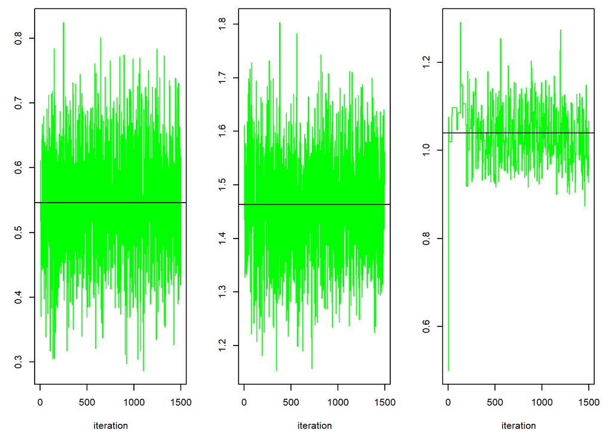

```r
par(mfrow = c(1, 3), mai = c(.6, .4, .1, .2))
plot(mcmc.out[ , "beta0"], type = "l", xlab = "iteration",
     ylab = expression(beta[1]),col="green")
abline(h=mean(mcmc.out[ , "beta0"]))
plot(mcmc.out[ , "beta1"], type = "l", xlab = "iteration",
     ylab = expression(beta[2]),col="green")
abline(h=mean(mcmc.out[ , "beta1"]))
plot(mcmc.out[ , "sigma"], type = "l", xlab = "iteration",
     ylab = expression(sigma),col="green")
abline(h=mean(mcmc.out[ , "sigma"])) # note: should put burin
```

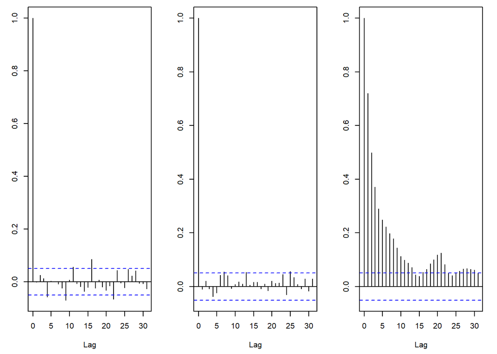

```r
par(mfrow = c(1, 3), mai = c(.6, .4, .1, .2))
acf(mcmc.out[, "beta0"])
acf(mcmc.out[, "beta1"])
acf(mcmc.out[, "sigma"])
```

- Plot MCMC information (traceplot, density plot,…rtc) from MCMC package.

```r
# Specify a dirction to save HTML
dirfil <- "C:\\Users\\chech\\Desktop\\2021 Fall\\BMTRY719 Bayesian\\nimble\\example\\mc-output"
mcmcplot(mcmc.out,dir=dirfil,filename = "output-SLR")
```

- **NOTE: sigma based on RW sampler need more burn-in period.**

```r
niter <- 1500
burn  <- 500
set.seed(1)
samples <- runMCMC(modelMCMC, niter = niter,nburnin = burn, nchains = 1)
```

```
## |-------------|-------------|-------------|-------------|
## |-------------------------------------------------------|
```

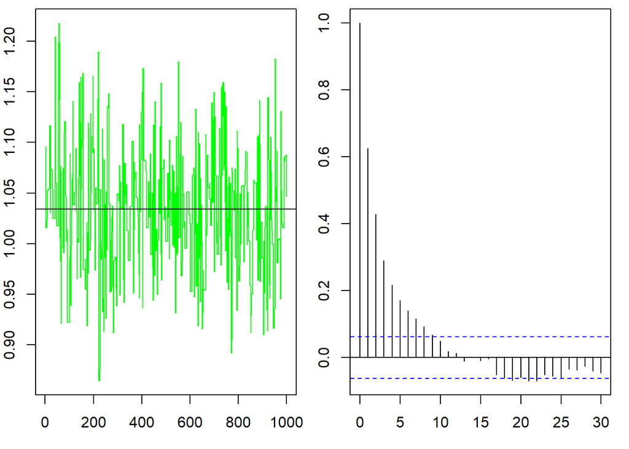

#### Step 5.2(second way): nimbleMCMC() function

```r
mcmc.out2 <- nimbleMCMC(code = code, constants = constants,
                       data = data, inits = inits,
                       nchains = 1, niter = 1500,
                       summary = TRUE, WAIC = TRUE,
                       monitors = c('beta0','beta1','sigma'))
```

```
## defining model...
```

```
## building model...
```

```
## setting data and initial values...
```

```
## running calculate on model (any error reports that follow may simply reflect missing values in model variables) ...
## checking model sizes and dimensions...
## checking model calculations...
## model building finished.
## Monitored nodes are valid for WAIC.
## compiling... this may take a minute. Use 'showCompilerOutput = TRUE' to see C++ compilation details.
## compilation finished.
## running chain 1...
```

```
## |-------------|-------------|-------------|-------------|
## |-------------------------------------------------------|
```

```r
names(mcmc.out2) # "samples" "summary" ""WAIC
```

```
## [1] "samples" "summary" "WAIC"
```

```r
# MCMC estimate
mcmc.out2$summary
```

```
##            Mean    Median    St.Dev. 95%CI_low 95%CI_upp
## beta0 0.5489887 0.5482222 0.08527928 0.3850698 0.7204529
## beta1 1.4646115 1.4659460 0.09222784 1.2820523 1.6482670
## sigma 1.0378817 1.0298306 0.06944478 0.9299482 1.1648377
```

```r
# Model fitting
mcmc.out2$WAIC
```

```
## [1] 439.5323
```

## Conjugate Posterior for $\sigma^2$ or $\tau$

- $y_i|x_i,\beta_0,\beta_1,\tau \sim N( \beta_0+\beta_1x_i,\tau^{-1})$ and $\tau\sim Gamma(a,b)$
- $\tau~\sim Gamma(a+n/2,b+\sum_{i=1}^{n}(y_i-\beta_0-\beta_1x_i)^2/2)$

```r
# Gamma prior for variance: GA(0.001,0.001)
code <- nimbleCode({
  for(i in 1:n) {y[i] ~ dnorm(beta0+beta1*x[i], tau = tau)}
  # if want to have conjugacy, need to specify tau (not sd)
  beta0 ~ dnorm(0, sd = 100)
  beta1 ~ dnorm(0, sd = 100)
  tau   ~ dgamma(shape = 0.001, rate = 0.001)
  var   <- 1/tau
  sigma <- sqrt(var)
})
```

- Use Inverse-Gamma to update variance

```r
###########
# NOT RUN #
###########
# Inverse gamma for precision: Inv-ga(1,1)
code <- nimbleCode({
  for(i in 1:n) {y[i] ~ dnorm(beta0+beta1*x[i], var = var)}
  # if want to have conjugacy, need to specify var
 beta0 ~ dnorm(0, sd = 100)
  beta1 ~ dnorm(0, sd = 100)
  var   ~ dinvgamma(shape = 0.0001, rate = 0.0001) # non-informative prior of
                                                   # inverse gamma (1,1)
  tau   <- 1/var
  sigma <- sqrt(var)
})
```

- Check the conjugacy for precision and variance

```r
constants <- list(n = n, p = p, x = x)
data <- list(y = y)
inits <- list(beta0=0, beta1 = 0, tau = 1)
# nimbleModel: check code specifcation is correct
model <- nimbleModel(code, constants = constants, data = data, inits = inits)
```

```
## defining model...
```

```
## building model...
```

```
## setting data and initial values...
```

```
## running calculate on model (any error reports that follow may simply reflect missing values in model variables) ...
## checking model sizes and dimensions...
## model building finished.
```

```r
# Model configuration
modelConf <- configureMCMC(model, print = TRUE)
```

```
## ===== Monitors =====
## thin = 1: beta0, beta1, tau
## ===== Samplers =====
## conjugate sampler (3)
##   - beta0
##   - beta1
##   - tau
```

```r
modelConf$printSamplers()               # show conjugacy
```

```
## [1] conjugate_dnorm_dnorm_additive sampler: beta0
## [2] conjugate_dnorm_dnorm_linear sampler: beta1
## [3] conjugate_dgamma_dnorm_identity sampler: tau
```

```r
modelConf$addMonitors(c("var","sigma")) # add monitor of var & sigma
```

```
## thin = 1: beta0, beta1, tau, var, sigma
```

```r
# Compile model
Cmodel <- compileNimble(model)
```

```
## compiling... this may take a minute. Use 'showCompilerOutput = TRUE' to see C++ compilation details.
```

```
## compilation finished.
```

```r
Cmodel$beta0
```

```
## [1] 0
```

```r
# Biuld MCMC
modelMCMC <- buildMCMC(modelConf)
modelMCMC <- compileNimble(modelMCMC, project = model)
```

```
## compiling... this may take a minute. Use 'showCompilerOutput = TRUE' to see C++ compilation details.
## compilation finished.
```

```r
########
# MCMC #
########
niter <- 1500
burn  <- 0
set.seed(1)
samples <- runMCMC(modelMCMC, niter = niter,nburnin = burn, nchains = 1,
                   summary = T)
```

```
## running chain 1...
```

```
## |-------------|-------------|-------------|-------------|
## |-------------------------------------------------------|
```

```r
out<-samples$summary
kable(out,digits = 4, format = "html") %>% kable_styling(full_width = F)
```

|  | Mean | Median | St.Dev. | 95%CI_low | 95%CI_upp |
| --- | --- | --- | --- | --- | --- |
| beta0 | 0.5454 | 0.5448 | 0.0846 | 0.3817 | 0.7186 |
| beta1 | 1.4610 | 1.4606 | 0.0909 | 1.2831 | 1.6389 |
| sigma | 1.0335 | 1.0309 | 0.0603 | 0.9259 | 1.1614 |
| tau | 0.9458 | 0.9409 | 0.1095 | 0.7414 | 1.1664 |
| var | 1.0717 | 1.0628 | 0.1257 | 0.8574 | 1.3488 |

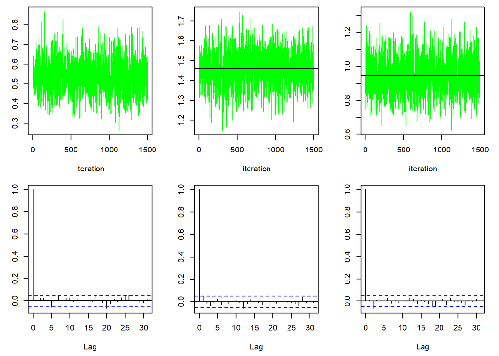

```r
mcmc.out<-samples$samples
par(mfrow = c(2, 3), mai = c(.6, .4, .1, .2))
plot(mcmc.out[ , "beta0"], type = "l", xlab = "iteration",
     ylab = expression(beta[1]),col="green")
abline(h=mean(mcmc.out[ , "beta0"]))
plot(mcmc.out[ , "beta1"], type = "l", xlab = "iteration",
     ylab = expression(beta[2]),col="green")
abline(h=mean(mcmc.out[ , "beta1"]))
plot(mcmc.out[ , "tau"], type = "l", xlab = "iteration",
     ylab = expression(sigma),col="green")
abline(h=mean(mcmc.out[ , "tau"]))

acf(mcmc.out[, "beta0"])
acf(mcmc.out[, "beta1"])
acf(mcmc.out[, "tau"])
```

### Conjugate (‘Gibbs’) Samplers

- The current release of NIMBLE supports conjugate sampling of the relationships

| Prior | Sampling Distribution | Parameter |
| --- | --- | --- |
| Beta | Bernoulli | prob |
|  | Binomial | prob |
|  | Negative Binomial | prob |
| Dirichlet | Multinomial | prob |
|  | Categorical | prob |
| Flat | Normal | mean |
|  | Lognormal | meanlog |
| Gamma | Poisson | lambda |
|  | Normal | tau |
|  | Lognormal | taulog |
|  | Gamma | rate |
|  | Inverse Gamma | scale |
|  | Exponential | rate |
|  | Double Exponential | rate |
|  | Weibull | lambda |
| Normal | Normal | mean |
|  | Lognormal | meanlog |
| Multivariate Normal | Multivariate Normal | mean |
| Wishart | Multivariate Normal | prec |
| Inverse Wishart | Multivariate Normal | cov |

## Coda Package with Nimble

- Effective sample size
- Geweke Diagnostic
- Gelman-Rubin Diagnostic

```r
# Effective Sample Sizes
  effectiveSize(mcmc.out[500:1000,"beta1"])
```

```
## var1
##  501
```

```r
  effectiveSize(mcmc.out[500:1000,"tau"])
```

```
## var1
##  501
```

```r
# Geweke Diagnostics
  geweke.diag(mcmc.out[500:1000,"beta1"])$z
```

```
##       var1
## -0.3710201
```

```r
  2*pnorm(geweke.diag(mcmc.out[500:1000,"beta1"])$z)
```

```
##      var1
## 0.7106226
```

```r
# Gelman-Rubin (two chains)
  niter <- 1500
  burn  <- 0
  set.seed(1)
  samples <- runMCMC(modelMCMC, niter = niter,nburnin = burn, nchains = 2)
```

```
## running chain 1...
```

```
## |-------------|-------------|-------------|-------------|
## |-------------------------------------------------------|
```

```
## running chain 2...
```

```
## |-------------|-------------|-------------|-------------|
## |-------------------------------------------------------|
```

```r
  mcmc.out.c1 <- samples$chain1
  mcmc.out.c2 <- samples$chain2

  tauc1 <- mcmc(mcmc.out.c1[501:1500,"tau"])
  tauc2 <- mcmc(mcmc.out.c2[501:1500,"tau"])

  taulist <- mcmc.list(tauc1,tauc2)
  gelman.diag(taulist,autoburnin = F)
```

```
## Potential scale reduction factors:
##
##      Point est. Upper C.I.
## [1,]          1          1
```